# Methylation Vignette - Toy Data

Connor Smith

Vignette followed from paper: *A cross-package Bioconductor workflow for analysing methylation array data*

# Introduction

- Two types of assays
  - Infinum I
    - 2 bead types: methylated and unmethylated
  - Infinum II
    - 1 bead
- Reported as one of two values
  - $\beta$-values
    - $\beta = M/(M+U)$
    - Small offset of $\alpha$ can be added to denominator to avoid dividing by small numbers
      - this is the default behavior for *getBeta* function from *minfi*
      - default is 100
    - preferred for describing methylation levels and visualization
  - M-value
    - $M = log_2(M/U)$
    - Small offset of $\alpha$ can be added to numerator and denominator to avoid dividing by 0
      - this is **not** default behavior for *getM* function from *minfi*
    - preferred/required for statistical testing

# Vignette

Setup data variable and verify its contents

```r
dataDirectory <- system.file("extdata", package = "methylationArrayAnalysis")
list.files(dataDirectory, recursive = TRUE)
#output hidden for brevity
```

## Dataset notes

- 10 samples
  - 4 different sorted T-cell types (naive, rTreg, act_naive, act_rTreg)
  - 3 individuals (healthy males, taken from buffy coat)
    - M28, 29, 30
- Packages designed for reading Methylation data
  - *minfi*
  - *missMethyl*
  - *wateRmelon*
  - *methylumi*
  - *ChAMP*
  - *charm*
- *minfi* and *methylumi* allow for reading of raw IDAT files
  - store in seperate data types
  - not trivial to convert between them
- *limma* (developed for gene expression microarray analysis) is also popular for analyzing methylation array data
  - easily converts to R matrix

## Load Data

```r
library(limma)
library(minfi)
library(IlluminaHumanMethylation450kanno.ilmn12.hg19)
library(IlluminaHumanMethylation450kmanifest)
library(RColorBrewer)
library(missMethyl)
library(matrixStats)
library(minfiData)
library(Gviz)
library(DMRcate)
library(stringr)
```

- Methylation specific packages
  - *minfi*
  - *IlluminaHumanMethylation450kanno.ilmn12.hg19*
  - *IlluminaHumanMethylation450kmanifest*
  - *missMethyl*
  - *minfiData*
  - *DMRcate*
- Vizualization packages
  - *RColorBrewer*
  - *Gviz*
- Others
  - *limma* used to test for differential methylation
  - *matrixStats* and *stringr* contribute functions to workflow
  - *IlluminaHumanMethylation450kmanifest* provides annotation info for all of the 450k probes

```r
ann450k = getAnnotation(IlluminaHumanMethylation450kanno.ilmn12.hg19) #minfi function
#head(ann450k)
#removed for brevity
```

### Notes about Bead Array Files

- Illumina Methylation data is output as a collection of Intesity Data (IDAT) files
  - each file is ~8MB
- Import using *minfi* function **read.metharray.sheet**
  - requires IDAT file and a sample sheet
    - sample sheet is a csv with one row for each sample
  - import creates a data frame whith 1 row for each sample and several columns
  - column **BaseName** is created to store the location of IDAT file associated with each sample

```r
targets <- read.metharray.sheet(dataDirectory, pattern="SampleSheet.csv") #minfi function
```

```
[read.metharray.sheet] Found the following CSV files:
```

```
[1] "C:/Users/conno/Documents/R/win-library/3.4/methylationArrayAnalysis/extdata/SampleSheet.csv"
```

- To read in the raw intensity data, we use **read.metharry.exp** from *minfi*
  - creates **RGChannelSet** object with raw intensity for red and green channels for each sample
  - good time to rename the samples in resulting object

```r
# read in intensities
rgSet <- read.metharray.exp(targets=targets)
# print object info
rgSet
```

```
class: RGChannelSet
dim: 622399 11
metadata(0):
assays(2): Green Red
rownames(622399): 10600313 10600322 ... 74810490 74810492
rowData names(0):
colnames(11): 6264509100_R01C01 6264509100_R02C01 ... 6264509100_R04C02 5975827018_R06C02
colData names(10): Sample_Name Sample_Well ... Basename filenames
Annotation
  array: IlluminaHumanMethylation450k
  annotation: ilmn12.hg19
```

```r
#rename samples, using code straight from vignette
targets$ID <- paste(targets$Sample_Group, targets$Sample_Name, sep=".")
sampleNames(rgSet) <- targets$ID
# reprint object info after renaming samples
rgSet
```

```
class: RGChannelSet
dim: 622399 11
metadata(0):
assays(2): Green Red
rownames(622399): 10600313 10600322 ... 74810490 74810492
rowData names(0):
colnames(11): naive.1 rTreg.2 ... act_rTreg.10 birth.11
colData names(10): Sample_Name Sample_Well ... Basename filenames
Annotation
  array: IlluminaHumanMethylation450k
  annotation: ilmn12.hg19
```

## Quality Control

- Want to screen detection p-values for quality
  - low value = good
  - high value (> 0.01) = bad
- *minfi* function **detectionP** compares total signal $M+U$ for each probe to background signal level
  - background signal level estimated from negative control probes
- plot mean detection value for each sample to get idea of overall quality

```r
detP <- detectionP(rgSet)
head(detP)
```

```
           naive.1 rTreg.2  act_naive.3 naive.4 act_naive.5 act_rTreg.6 naive.7      rTreg.8 act_naive.9 act_rTreg.10  birth.11
cg00050873       0       0 0.000000e+00       0 0.00000e+00           0       0 0.000000e+00           0 0.000000e+00 0.0000000
cg00212031       0       0 0.000000e+00       0 0.00000e+00           0       0 0.000000e+00           0 0.000000e+00 0.0000000
cg00213748       0       0 1.181832e-12       0 8.21565e-15           0       0 1.469801e-05           0 1.365951e-08 0.6735224
cg00214611       0       0 0.000000e+00       0 0.00000e+00           0       0 0.000000e+00           0 0.000000e+00 0.7344451
cg00455876       0       0 0.000000e+00       0 0.00000e+00           0       0 0.000000e+00           0 0.000000e+00 0.0000000
cg01707559       0       0 0.000000e+00       0 0.00000e+00           0       0 0.000000e+00           0 0.000000e+00 0.0000000
```

**NOTE**: already see very low quality in *birth.11* data, which was included as an example of poor data

```r
pal <- brewer.pal(8, "Dark2") # creates a nice looking palette for readable/consistent plotting
par(mfrow=c(1,2))
# plot normal view
barplot(colMeans(detP),
        col=pal[factor(targets$Sample_Group)],
        las=2,
        cex.names=0.8,
        ylab="Mean detection p-values")
abline(h=0.05,
       col="red")
```

```r
legend("topleft",
       legend=levels(factor(targets$Sample_Group)),
       fill=pal,
       bg="white")
# plot zoomed view
barplot(colMeans(detP),
        col=pal[factor(targets$Sample_Group)],
        las=2,
        cex.names=0.8,
        ylim=c(0,0.002),
        ylab="Mean detection p-values")
```

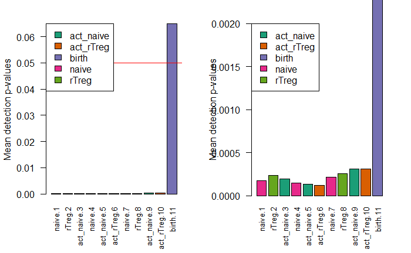

```r
abline(h=0.05,
       col="red")
legend("topleft",
       legend=levels(factor(targets$Sample_Group)),
       fill=pal,
       bg="white")
```

- *minfi* function **qcReport** generates further quality control plots
  - run through *minfi* [vignette](http://bioconductor.org/packages/release/bioc/vignettes/minfi/inst/doc/minfi.pdf) for further information on these

```r
qcReport(rgSet, sampNames=targets$ID, sampGroups = targets$Sample_Group, pdf = "qcReport.pdf") # minfi function
```

- Remove poor quality samples from further analysis (anything with p-value over 0.05)

```r
# create subset based on means detection p values
keep <- colMeans(detP) < 0.05
# remove from samples
rgSet <- rgSet [,keep]
# view details to see that birth.11 has been removed
rgSet
```

```
class: RGChannelSet
dim: 622399 10
metadata(0):
assays(2): Green Red
rownames(622399): 10600313 10600322 ... 74810490 74810492
rowData names(0):
colnames(10): naive.1 rTreg.2 ... act_naive.9 act_rTreg.10
colData names(10): Sample_Name Sample_Well ... Basename filenames
Annotation
  array: IlluminaHumanMethylation450k
  annotation: ilmn12.hg19
```

```r
# remove from targets data
targets <- targets[keep,]
# view first couple rows to see that birth.11 has been removed
targets[,1:5]
```

|  | Sample_Name | Sample_Well | Sample_Source | Sample_Group | Sample_Label |
| --- | --- | --- | --- | --- | --- |
| 1 | 1 | A1 | M28 | naive | naive |
| 2 | 2 | B1 | M28 | rTreg | rTreg |
| 3 | 3 | C1 | M28 | act_naive | act_naive |
| 4 | 4 | D1 | M29 | naive | naive |
| 5 | 5 | E1 | M29 | act_naive | act_naive |
| 6 | 6 | F1 | M29 | act_rTreg | act_rTreg |
| 7 | 7 | G1 | M30 | naive | naive |
| 8 | 8 | H1 | M30 | rTreg | rTreg |
| 9 | 9 | A2 | M30 | act_naive | act_naive |
| 10 | 10 | B2 | M30 | act_rTreg | act_rTreg |

```r
# remove from detection p-value table
dim(detP)
```

```
[1] 485512     11
```

```r
detP <- detP[,keep]
dim(detP)
```

```
[1] 485512     10
```

## Normalization

- good “rule of thumb” functions within *minfi*
  - **preprocessFunnorm** best for datasets with global methylation differences such as cancer/normal or vastly different tissue types
  - **preprocessQuantile** best when you do not expect global differences (like using a single tissue)
- This vignette uses the **preprocessQuantile** as the cell types being evaluated are all blood cell types and reltively similar
- after normalization, data is stored in a **GenomicRatioSet** object
- Vignette runs the **preprocessQuantile** function with defaults, which are as follows:
  - fixOutliers = TRUE $\Rightarrow$ corrects for very low intensities near 0 using the *minfi* function **fixMethOutliers**
  - removeBadSamples = FALSE $\Rightarrow$ removes values based on badSampleCutoff for Meth and Unmeth (seperately) for each sample
  - badSampleCutoff = 10.5 $\Rightarrow$ default value to use for removeBadSamples
  - quantileNormalize = TRUE $\Rightarrow$ specifies to use quantiles
  - stratified = TRUE $\Rightarrow$ specifies normalize within genomic region strata
  - mergeManifest = FALSE $\Rightarrow$ when true, will merge manifest data into output
  - sex = NULL $\Rightarrow$ when null uses *minfi* **getSex** function to guess the sex of the sample based on copy number information
  - verbose = TRUE $\Rightarrow$ tells the function to include verbose comments in the output

```r
# store stratified quantile normalized data into a new GenomicRatioSet object
mSetSq <- preprocessQuantile(rgSet)
```

```
[preprocessQuantile] Mapping to genome.
[preprocessQuantile] Fixing outliers.
An inconsistency was encountered while determining sex. One possibility is that only one sex is present. We recommend further checks, for example with the plotSex function.[preprocessQuantile] Quantile normalizing.
```

```r
# store raw, preprocessed data for plotting
mSetRaw <- preprocessRaw(rgSet)
```

```r
# vizualize effect of normalization
par(mfrow=c(1,2))
# raw plot
densityPlot(rgSet, # i thought that we should use getBeta(mSetRaw), but this results in the same graph but I do not know why
            sampGroups = targets$Sample_Group,
            main = "Raw",
            legend = FALSE)
legend("top",
       legend = levels(factor(targets$Sample_Group)),
       text.col = brewer.pal(8,"Dark2"))
```

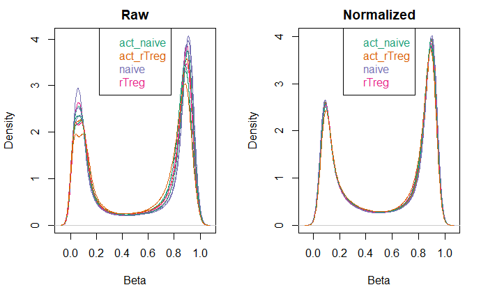

```r
# normalized plot
densityPlot(getBeta(mSetSq),
            sampGroups = targets$Sample_Group,
            main = "Normalized",
            legend = FALSE)
legend("top",
       legend = levels(factor(targets$Sample_Group)),
       text.col = brewer.pal(8,"Dark2"))
```

## Data Exploration

- Principal component analysis is always a good start to understand sources of variation ({shannon voice}: watch for batch effects!)

```r
par(mfrow=c(1,2))
# plot pc 1 and 2 labeled by sample group (cell type)
plotMDS(getM(mSetSq),
        top=1000,
        gene.selection = "common", # specifies taking all genes into consideration as opposed to pairwise which focuses on strongest association for this pair
        col = pal[factor(targets$Sample_Group)]) #limma function
legend("top",
       legend = levels(factor(targets$Sample_Group)),
       text.col = pal,
       bg = "white",
       cex = 0.7)
```

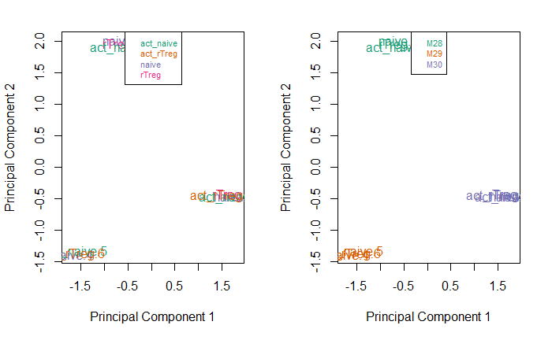

```r
# plot pc 1 and 2 labeled by sample donor
plotMDS(getM(mSetSq),
        top=1000,
        gene.selection = "common", # specifies taking all genes into consideration as opposed to pairwise which focuses on strongest association for this pair
        col = pal[factor(targets$Sample_Source)]) #limma function
legend("top",
       legend = levels(factor(targets$Sample_Source)),
       text.col = pal,
       bg = "white",
       cex = 0.7)
```

We can see here that the variation is caused by samples being from different individuals. We will look at higher dimensions to find other possible sources of variation.

```r
par(mfrow=c(1,3))
# plot pca between pc 1 and 3
plotMDS(getM(mSetSq),
        top = 1000,
        gene.selection="common",
        col = pal[factor(targets$Sample_Group)],
        dim = c(1,3))
legend("top",
       legend=levels(factor(targets$Sample_Group)),
       text.col=pal,
       cex=0.7,
       bg="white")
```

```r
# plot pca between pc 2 and 3
plotMDS(getM(mSetSq),
        top=1000,
        gene.selection="common",
        col=pal[factor(targets$Sample_Group)],
        dim=c(2,3))
legend("topleft",
       legend=levels(factor(targets$Sample_Group)),
       text.col=pal,
       cex=0.7,
       bg="white")
```

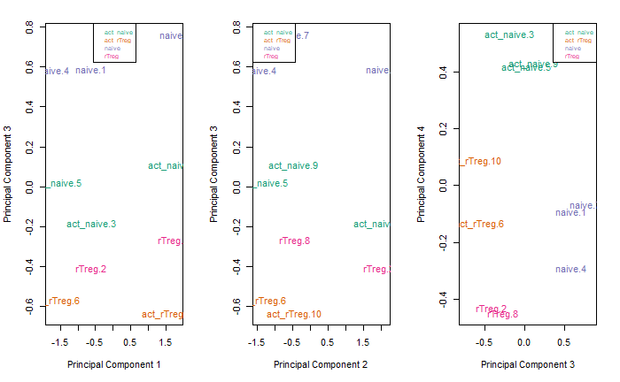

```r
# plot pcs between pc 3 and 4
plotMDS(getM(mSetSq),
        top=1000,
        gene.selection="common",
        col=pal[factor(targets$Sample_Group)],
        dim=c(3,4))
legend("topright",
       legend=levels(factor(targets$Sample_Group)),
       text.col=pal,
       cex=0.7,
       bg="white")
```

PC3 and PC4 seem to seperate the different cell types well. We will keep these analyses in mind when working downstream.

## Filtering

Remove poorly performing probes before differential methylation analysis to reduce dimensionality and reduce the multiple testing penalty. A cut off detection p-value of 0.01 was used.

```r
# verify that all of the objects are in the correct order
detP <- detP[match(featureNames(mSetSq),rownames(detP)),]
# identify probes that failed in one or more samples
keep <- rowSums(detP < 0.01) ==ncol(mSetSq)
table(keep)
```

```
keep
 FALSE   TRUE
   977 484535
```

```r
# subset the mSetSq to only include the keepers
mSetSqFlt <- mSetSq[keep,]
# print details to see change
mSetSqFlt
```

```
class: GenomicRatioSet
dim: 484535 10
metadata(0):
assays(2): M CN
rownames(484535): cg13869341 cg14008030 ... cg08265308 cg14273923
rowData names(0):
colnames(10): naive.1 rTreg.2 ... act_naive.9 act_rTreg.10
colData names(11): Sample_Name Sample_Well ... filenames predictedSex
Annotation
  array: IlluminaHumanMethylation450k
  annotation: ilmn12.hg19
Preprocessing
  Method: Raw (no normalization or bg correction)
  minfi version: 1.24.0
  Manifest version: 0.4.0
```

### Notes for use in the future

While this one is all male and would not need it, it is common to need to remove probes on X/Y chromosomes when samples are from a mix of male and female. Additionally, you will want to remove probes that exist in locations with known SNPs for the disease you are investigating. Examples of both of these are listed below:

```r
# enable this code if your data includes male and female
# keep <- !(featureNames(mSetSqFlt) %in% ann450k$Name[ann450k$chr %in% c("chrX","chrY")])
```

Luckily, *minfi* has a built in function to remove probes that contain CpG site SNPs, **dropLociWithSnps**  
By default, **dropLociWithSnps** has the following settings: - snps = c(“CpG”,“SBE”) $\Rightarrow$ removes all probes that contain a single-nucleotide polymorphism (SNP) or a single base extension (SBE)  
- maf = 0 $\Rightarrow$ sets the minor allele frequency, which is a threshold by which to filter probes out. If left at 0, it will remove all probes with any SNPs

```r
# remove probes with SNPs at CpG site
mSetSqFlt <- dropLociWithSnps(mSetSqFlt)
mSetSqFlt
```

```
class: GenomicRatioSet
dim: 467351 10
metadata(0):
assays(2): M CN
rownames(467351): cg13869341 cg14008030 ... cg08265308 cg14273923
rowData names(0):
colnames(10): naive.1 rTreg.2 ... act_naive.9 act_rTreg.10
colData names(11): Sample_Name Sample_Well ... filenames predictedSex
Annotation
  array: IlluminaHumanMethylation450k
  annotation: ilmn12.hg19
Preprocessing
  Method: Raw (no normalization or bg correction)
  minfi version: 1.24.0
  Manifest version: 0.4.0
```

Additionally, we will remove cross-reactive probes (aka multi-mapping probes), as annotated by Chen et al.

```r
# assemble list of cross reactive probes
xReactiveProbes <- read.csv(file = paste(dataDirectory,
                                         "48639-non-specific-probes-Illumina450k.csv",
                                         sep="/"),
                            stringsAsFactors = FALSE)
# identify probes in set that are cross reactive
keep <- !(featureNames(mSetSqFlt) %in% xReactiveProbes$TargetID)
table(keep)
```

```
keep
 FALSE   TRUE
 27433 439918
```

```r
mSetSqFlt <- mSetSqFlt[keep,]
mSetSqFlt
```

```
class: GenomicRatioSet
dim: 439918 10
metadata(0):
assays(2): M CN
rownames(439918): cg13869341 cg24669183 ... cg08265308 cg14273923
rowData names(0):
colnames(10): naive.1 rTreg.2 ... act_naive.9 act_rTreg.10
colData names(11): Sample_Name Sample_Well ... filenames predictedSex
Annotation
  array: IlluminaHumanMethylation450k
  annotation: ilmn12.hg19
Preprocessing
  Method: Raw (no normalization or bg correction)
  minfi version: 1.24.0
  Manifest version: 0.4.0
```

### Revisit MDS Plots

After filtering, revisit the MDS plots to look for changes.

```r
par(mfrow=c(1,2))
# plot pca of 1 and 2 by cell type
plotMDS(getM(mSetSqFlt),
        top=1000,
        gene.selection="common",
        col=pal[factor(targets$Sample_Group)],
        cex=0.8)
legend("right",
       legend=levels(factor(targets$Sample_Group)),
       text.col=pal,
       cex=0.65,
       bg="white")
```

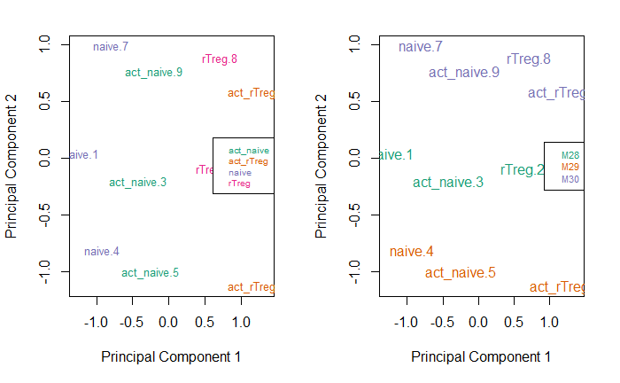

```r
# plot pca of 1 and 2 by individual
plotMDS(getM(mSetSqFlt),
        top=1000,
        gene.selection="common",
        col=pal[factor(targets$Sample_Source)])
legend("right",
       legend=levels(factor(targets$Sample_Source)),
       text.col=pal,
       cex=0.7,
       bg="white")
```

We can still see some clustering of PC2 by the individual, but also some seperation of PC1 by cell type.

```r
par(mfrow=c(1,3))
# pca plot of pc 1 and 3 by individual
plotMDS(getM(mSetSqFlt),
        top=1000,
        gene.selection="common",
        col=pal[factor(targets$Sample_Source)],
        dim=c(1,3))
legend("right",
       legend=levels(factor(targets$Sample_Source)),
       text.col=pal,
       cex=0.7,
       bg="white")
```

```r
# pca plot of pc 2 and 3 by individual
plotMDS(getM(mSetSqFlt),
        top=1000,
        gene.selection="common",
        col=pal[factor(targets$Sample_Source)],
        dim=c(2,3))
legend("topright",
       legend=levels(factor(targets$Sample_Source)),
       text.col=pal,
       cex=0.7,
       bg="white")
```

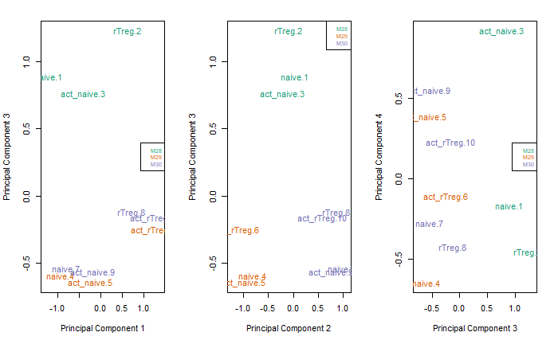

```r
# pca plot of pc 3 and 4 by individual
plotMDS(getM(mSetSqFlt),
        top=1000,
        gene.selection="common",
        col=pal[factor(targets$Sample_Source)],
        dim=c(3,4))
legend("right",
       legend=levels(factor(targets$Sample_Source)),
       text.col=pal,
       cex=0.7,
       bg="white")
```

## Calculating M and $\beta$ values

M-values $\Rightarrow$ great for statistical analysis  
$\beta$-values $\Rightarrow$ great for visualization

```r
# calculate M-values
mVals <- getM(mSetSqFlt) # minfi function
head(mVals[,1:5])
```

```
             naive.1   rTreg.2 act_naive.3   naive.4 act_naive.5
cg13869341  2.421276  2.515948    2.165745  2.286314    2.109441
cg24669183  2.169414  2.235964    2.280734  1.632309    2.184435
cg15560884  1.761176  1.577578    1.597503  1.777486    1.764999
cg01014490 -3.504268 -3.825119   -5.384735 -4.537864   -4.296526
cg17505339  3.082191  3.924931    4.163206  3.255373    3.654134
cg11954957  1.546401  1.912204    1.727910  2.441267    1.618331
```

```r
bVals <- getBeta(mSetSqFlt)
head(bVals[,1:5])
```

```
              naive.1    rTreg.2 act_naive.3    naive.4 act_naive.5
cg13869341 0.84267937 0.85118462   0.8177504 0.82987650  0.81186174
cg24669183 0.81812908 0.82489238   0.8293297 0.75610281  0.81967323
cg15560884 0.77219626 0.74903910   0.7516263 0.77417882  0.77266205
cg01014490 0.08098986 0.06590459   0.0233755 0.04127262  0.04842397
cg17505339 0.89439216 0.93822870   0.9471357 0.90520570  0.92641305
cg11954957 0.74495496 0.79008516   0.7681146 0.84450764  0.75431167
```

```r
# plot m and beta values
par(mfrow=c(1,2))
# plot beta values
densityPlot(bVals,
            sampGroups = targets$Sample_Group,
            main = expression(paste(beta,"-values",sep = "")),
            legend = FALSE,
            xlab = expression(paste(beta,"-values",sep = "")))
legend("top",
       legend = levels(factor(targets$Sample_Group)),
       text.col = brewer.pal(8,"Dark2"))
```

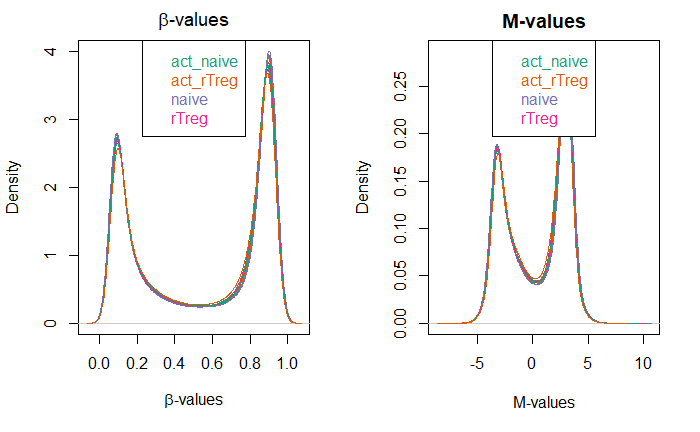

```r
# plot M values
densityPlot(mVals,
            sampGroups = targets$Sample_Group,
            main = "M-values",
            legend = FALSE,
            xlab = "M-values")
legend("top",
       legend = levels(factor(targets$Sample_Group)),
       text.col = brewer.pal(8,"Dark2"))
```

## Pairwise Comparison

- Need to adjust for multiple testing
  - do this by setting cutoff for FDR of 5%

```r
# factor of interest
cellType <- factor(targets$Sample_Group)
# account for individual effect
individual <- factor(targets$Sample_Source)
# create a design matrix
design <- model.matrix(~0+cellType+individual,
                       data = targets)
colnames(design) <- c(levels(cellType),levels(individual)[-1])
# fit linear model
fit <- lmFit(mVals, design)
# create contrast matrix for specific comparisons
contMatrix <- makeContrasts(naive-rTreg,
                           naive-act_naive,
                           rTreg-act_rTreg,
                           act_naive-act_rTreg,
                           levels=design)
contMatrix
```

```
           Contrasts
Levels      naive - rTreg naive - act_naive rTreg - act_rTreg act_naive - act_rTreg
  act_naive             0                -1                 0                     1
  act_rTreg             0                 0                -1                    -1
  naive                 1                 1                 0                     0
  rTreg                -1                 0                 1                     0
  M29                   0                 0                 0                     0
  M30                   0                 0                 0                     0
```

```r
# fit the contrasts
fit2 <- contrasts.fit(fit,contMatrix)
fit2 <- eBayes(fit2)
# look at numbers of differentially methylated CpGs at false disco rate < 0.05
summary(decideTests(fit2)) #default p of 0.05
```

```
       naive - rTreg naive - act_naive rTreg - act_rTreg act_naive - act_rTreg
Down            1618               400                 0                   559
NotSig        436897            439291            439918                438440
Up              1403               227                 0                   919
```

We want to calculate B-statistic, which is the log-odds of differential methylation.

## Results from first contrast

```r
# get table of results for 1st contrast (naive - rTreg)
ann450kSub <- ann450k[match(rownames(mVals), ann450k$Name),
                      c(1:4,12:19,24:ncol(ann450k))]
DMPs <- topTable(fit2,
                 number = Inf,
                 coef = 1,
                 genelist = ann450kSub)
#head(DMPs)
write.table(DMPs, file="DMPs.csv", sep=",", row.names=FALSE)
```

Plot some of the pairwise comparisons by group to see if they make sense. We see clustering by cell type at different B statistics. The table is sorted in order by B statistic, so the top 4 will be the most significant results.

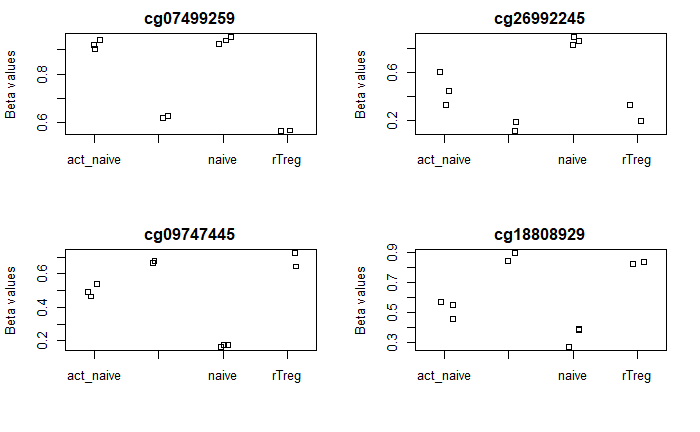

```r
# plot the top 4 most significantly differentially methylated CpGs
par(mfrow=c(2,2))
sapply(rownames(DMPs)[1:4], function(cpg){
  plotCpg(bVals, cpg=cpg, pheno=targets$Sample_Group, ylab = "Beta values")
})
```

## Differential Methylation Analysis of Regions

```r
myAnnotation <- cpg.annotate(object = mVals, datatype = "array", what = "M",
                             analysis.type = "differential", design = design,
                             contrasts = TRUE, cont.matrix = contMatrix,
                             coef = "naive - rTreg", arraytype = "450K")
```

```
Your contrast returned 3021 individually significant probes. We recommend the default setting of pcutoff in dmrcate().
```

```r
str(myAnnotation)
```

```
List of 7
 $ ID    : Factor w/ 439918 levels "cg00000029","cg00000108",..: 232388 391918 260351 19418 289954 202723 379224 278730 105471 57735 ...
 $ stat  : num [1:439918] 0.0489 -2.0773 0.7711 -0.0304 -0.764 ...
 $ CHR   : Factor w/ 24 levels "chr1","chr10",..: 1 1 1 1 1 1 1 1 1 1 ...
 $ pos   : int [1:439918] 15865 534242 710097 714177 720865 758829 763119 779995 805102 805338 ...
 $ betafc: num [1:439918] 0.00039 -0.04534 0.01594 0.00251 -0.00869 ...
 $ indfdr: num [1:439918] 0.994 0.565 0.872 0.997 0.873 ...
 $ is.sig: logi [1:439918] FALSE FALSE FALSE FALSE FALSE FALSE ...
 - attr(*, "row.names")= int [1:439918] 1 2 3 4 5 6 7 8 9 10 ...
 - attr(*, "class")= chr "annot"
```

```r
DMRs <- dmrcate(myAnnotation, lambda=1000, C=2) # lambda 1000 specifies distance between unique clumps of CpG sites
```

[output not shown]

```r
head(DMRs)
```

| ID | weights | CHR | pos | betafc | indfdr | is.sig | raw | fdr | sig | step.dmr |
| --- | --- | --- | --- | --- | --- | --- | --- | --- | --- | --- |
| cg13869341 | 0.048900350 | chr1 | 15865 | 3.904490e-04 | 0.994425570 | FALSE | 9.609987e-01 | 9.771514e-01 | FALSE | NA |
| cg24669183 | 2.077317607 | chr1 | 534242 | -4.533666e-02 | 0.564802555 | FALSE | 3.777226e-02 | 1.558015e-01 | FALSE | NA |
| cg15560884 | 0.771100956 | chr1 | 710097 | 1.594487e-02 | 0.871652247 | FALSE | 4.406471e-01 | 6.682601e-01 | FALSE | NA |
| cg01014490 | 0.030427134 | chr1 | 714177 | 2.507518e-03 | 0.996549138 | FALSE | 9.757264e-01 | 9.853865e-01 | FALSE | NA |
| cg17505339 | 0.764032661 | chr1 | 720865 | -8.692147e-03 | 0.873165074 | FALSE | 4.448478e-01 | 6.714860e-01 | FALSE | NA |
| cg11954957 | 0.999508126 | chr1 | 758829 | -3.280214e-02 | 0.822236975 | FALSE | 3.175486e-01 | 5.636786e-01 | FALSE | NA |
| cg23803172 | 0.633019742 | chr1 | 763119 | 4.170277e-03 | 0.900085813 | FALSE | 5.267208e-01 | 7.315070e-01 | FALSE | NA |
| cg16736630 | 4.364114693 | chr1 | 779995 | -1.310623e-01 | 0.144046358 | FALSE | 1.276386e-05 | 2.808790e-04 | FALSE | NA |
| cg05898754 | 0.789446344 | chr1 | 805102 | -2.261909e-02 | 0.868018796 | FALSE | 4.867433e-02 | 1.838033e-01 | FALSE | NA |
| cg03128332 | 0.329583927 | chr1 | 805338 | 1.105222e-02 | 0.955045220 | FALSE | 2.558356e-02 | 1.202229e-01 | FALSE | NA |

[output cut: 990 more lines]

|  | coord | no.cpgs | minfdr | Stouffer | maxbetafc | meanbetafc |
| --- | --- | --- | --- | --- | --- | --- |
| 457 | chr17:57915665-57918682 | 12 | 4.957890e-91 | 6.639928e-10 | 0.39828619 | 0.313161140 |
| 733 | chr3:114012316-114012912 | 5 | 1.622885e-180 | 1.515378e-07 | 0.54342774 | 0.425162160 |
| 469 | chr17:74639731-74640078 | 6 | 9.516873e-90 | 1.527961e-07 | -0.25286449 | -0.195190350 |
| 1069 | chrX:49121205-49122718 | 6 | 6.753751e-84 | 2.936984e-07 | 0.45290884 | 0.300624233 |
| 492 | chr18:21452730-21453131 | 7 | 5.702319e-115 | 7.674943e-07 | -0.38674742 | -0.254608898 |
| 186 | chr10:135202522-135203200 | 6 | 1.465070e-65 | 7.918224e-07 | 0.28031575 | 0.229341870 |
| 8 | chr1:7999572-8001309 | 6 | 4.693567e-62 | 1.567226e-06 | 0.33915833 | 0.234115465 |
| 269 | chr12:89743788-89745192 | 11 | 1.381391e-109 | 1.738269e-06 | -0.29171817 | -0.182073038 |
| 605 | chr2:158113471-158114424 | 7 | 1.979555e-52 | 2.754748e-06 | -0.25076274 | -0.134873065 |
| 863 | chr6:31544694-31546085 | 13 | 1.185571e-80 | 2.782047e-06 | 0.28461128 | 0.166889411 |

[output cut: 538 more lines]

```
$cutoff
[1] 3.503989e-17
```

We want to visualize our results.

```r
# convert the regions to annotated genomic ranges
data(dmrcatedata)
results.ranges <- extractRanges(DMRs, genome = "hg19")

# set up the grouping variables and colours
groups <- pal[1:length(unique(targets$Sample_Group))]
names(groups) <- levels(factor(targets$Sample_Group))
cols <- groups[as.character(factor(targets$Sample_Group))]
samps <- 1:nrow(targets)
```

```r
# draw the plot for the top DMR
par(mfrow=c(1,1))
DMR.plot(ranges=results.ranges, dmr=1, CpGs=bVals, phen.col=cols, what = "Beta",
         arraytype = "450K", pch=16, toscale=TRUE, plotmedians=TRUE,
         genome="hg19", samps=samps)
```

[output not shown]